# Análisis de la Contaminación del Aire en Chile

**Minería de Datos CC5205-1**

Estudiantes:

Juan Pablo Bustamante  
Diego Alonso Carter  
Carolina Navarro P.  
Valentina  
Tomás Vallejo

## Introducción

En este segundo hito del proyecto de Minería de Datos sobre calidad del aire en Chile, el equipo retoma el trabajo desarrollado en el Hito 1 con un foco claro: responder de manera completa y ordenada las preguntas que se habían definido en la etapa anterior. A partir del conjunto de datos ya explorado y curado, se estructuran los análisis, visualizaciones y experimentos necesarios para dar una respuesta explícita a cada una de esas preguntas, revisando cuando es necesario los criterios de limpieza y las decisiones tomadas previamente.

La motivación de este hito se mantiene en la importancia de comprender la contaminación atmosférica en Chile y sus efectos sobre la salud y la calidad de vida de la población. Sin embargo, en esta etapa el énfasis está puesto en transformar las exploraciones iniciales en respuestas concretas: se busca que cada pregunta planteada en el Hito 1 cuente con un respaldo claro en los datos, en los gráficos y en las métricas utilizadas, de modo que el proyecto avance desde una fase descriptiva hacia una comprensión más estructurada del fenómeno analizado.

En este contexto, el Hito 2 se orienta a organizar el trabajo en torno a las preguntas originales, revisar y completar los análisis necesarios y dejar documentada la forma en que se arriba a cada respuesta. Más que introducir nuevos modelos complejos, se prioriza la claridad: vincular cada pregunta con los datos utilizados, los pasos realizados y las conclusiones alcanzadas, identificando también aquellos aspectos que podrían profundizarse en futuras etapas.

Los objetivos específicos de este hito son:

- Responder de forma explícita y sistemática las preguntas formuladas en el Hito 1 a partir del conjunto de datos de calidad del aire.
- Ordenar y documentar los análisis, visualizaciones y decisiones de preprocesamiento que permiten sustentar cada respuesta.
- Evaluar qué preguntas quedan completamente resueltas y en cuáles aparecen limitaciones de datos o de metodología.
- Identificar posibles líneas de trabajo futuro a partir de las respuestas obtenidas y de las brechas detectadas en el análisis.

## Exploración de Datos

En esta etapa inicial recopilamos y organizamos el conjunto de datos de calidad del aire proveniente del **Sistema de Información Nacional de Calidad del Aire (SINCA)**. El dataset integra información de **121 estaciones** distribuidas en distintas regiones de Chile, con registros predominantemente **horarios** que abarcan varios años, lo que proporciona alta densidad temporal y notable heterogeneidad entre estaciones de monitoreo.

Las variables incluyen contaminantes atmosféricos (PM2.5, PM10, SO₂, NO₂, O₃, CO), parámetros meteorológicos (temperatura, humedad relativa, dirección y velocidad del viento) y el **Índice de Calidad del Aire (ICAP)**. Es importante destacar que no todas las estaciones miden la totalidad de contaminantes o parámetros meteorológicos, y existen **cambios de instrumentación** y períodos con datos faltantes que generan coberturas desiguales y potenciales inconsistencias en las series temporales.

**Características principales del dataset identificadas:**

- **Resolución temporal y cobertura:** Series con granularidad horaria (ocasionalmente minutal o diaria), períodos de operación variables por estación y presencia de gaps temporales significativos.
- **Calidad y completitud de datos:** Coexistencia de datos validados, preliminares y no validados; necesidad de detección sistemática de *outliers* y caracterización de períodos con datos faltantes prolongados.
- **Estadística descriptiva:** Análisis de medianas e IQR para contaminantes particulados; identificación de distribuciones asimétricas y colas pesadas características de episodios de alta contaminación; cálculo de percentiles por estación y mes.
- **Patrones temporales:** Identificación de ciclos diurnos y semanales en PM y gases; análisis de estacionalidad; evaluación de autocorrelación (ACF) y persistencia de episodios contaminantes.
- **Relaciones bivariadas:** Construcción de matrices de correlación contaminante-meteorología (especialmente viento, temperatura y humedad); análisis de *scatter plots* condicionados por franja horaria y estación del año.
- **Visualizaciones exploratorias:** Generación de histogramas/KDE, gráficos de *series temporales* con bandas de confianza, *boxplots* mensuales, *heatmaps* de correlación y *rosas de viento* por estación.

**Estrategia de integración y armonización:** La diversidad de resoluciones temporales y coberturas exige implementar **resampling** y armonización temporal (unificación a resolución horaria/diaria manteniendo trazabilidad), además de **estandarización de unidades y nomenclatura**. El proceso contempla la fusión de tablas mediante claves `station_id` y `timestamp`, resolución de registros duplicados y verificación de **coherencia en zonas horarias**. Para casos con variables meteorológicas faltantes, se evaluará la **integración con fuentes externas** (reanálisis meteorológicos o redes complementarias) para minimizar sesgos en los análisis.

**Procesamiento y estandarización realizados:** Los datos fueron **organizados en un repositorio centralizado** y sometidos a limpieza inicial para **estandarizar** dos categorías principales: *datos meteorológicos* y *datos de contaminación*. Se normalizaron nombres de variables, formatos temporales y sistemas de unidades, documentándose la existencia de **mediciones a diferentes alturas** (ejemplo: viento a 2 m versus 10 m), aspecto que será considerado explícitamente en los análisis posteriores.

**Enriquecimiento contextual:** Se planifica **correlacionar** las series temporales con **eventos ambientales externos** (incendios forestales, tormentas de polvo, inversiones térmicas y otros fenómenos meteorológicos extremos) y aprovechar **información geoespacial** (coordenadas, altitud y características del entorno) para vincular cada estación con su ubicación y contexto territorial específico. Este enriquecimiento mejorará la interpretabilidad de patrones observados y la robustez de los modelos predictivos.

Con esta exploración sistemática caracterizamos la estructura del dataset, identificamos sus limitaciones principales y definimos oportunidades de integración, estableciendo los fundamentos metodológicos para las etapas subsecuentes de análisis estadístico y desarrollo de modelos predictivos.

# Preguntas de Investigación

## 1. Predicción de concentraciones de PM2.5

¿Es posible predecir con precisión la **concentración de PM2.5** a distintos horizontes temporales (t+1h, t+6h, t+24h) utilizando datos históricos y variables meteorológicas?

**Subpreguntas específicas:**

- ¿Cuál horizonte temporal proporciona predicciones más precisas y estables entre estaciones?
- ¿Qué variables (lags de PM2.5, velocidad del viento, humedad relativa, temperatura, variables calendáricas) contribuyen más significativamente a la capacidad predictiva?
- ¿Qué configuración de ventanas temporales (3h, 6h, 24h) mejora el error respecto a modelos de persistencia simple?

## 2. Detección de patrones anómalos

¿Qué **patrones anómalos** se manifiestan en las series horarias de contaminación atmosférica y bajo qué condiciones contextuales ocurren?

**Subpreguntas específicas:**

- ¿Los picos de concentración atípicos coinciden con condiciones de baja ventilación o eventos específicos (incendios, episodios de polvo, feriados)?
- ¿Existe variabilidad en la frecuencia de anomalías según la estación del año o entre días laborales versus fines de semana?

## 3. Impacto de zonas de sacrificio

¿Las estaciones ubicadas dentro o próximas a **zonas de sacrificio ambiental** presentan mayor frecuencia, duración e intensidad de episodios críticos comparadas con estaciones en áreas sin esta designación?

**Subpreguntas específicas:**

- ¿Cómo definir objetivamente la pertenencia (polígonos oficiales versus buffers de 3-5-10 km) y qué estaciones constituyen controles apropiados?
- ¿Cuál es la magnitud de las diferencias en tasas de ocurrencia, duración promedio y intensidad máxima de episodios críticos?

# Estrategia metodológica

**P1. ¿Hasta qué punto es posible predecir las concentraciones horarias de PM2.5 en Coyhaique II a distintos horizontes de tiempo?**

Para responder esta pregunta, el equipo construyó un pipeline de regresión multivariada para predecir el PM2.5 en Coyhaique II a tres horizontes temporales: 1, 6 y 24 horas en el futuro (t+1, t+6 y t+24). El enfoque se basó exclusivamente en la propia serie de PM2.5 y en variables temporales derivadas, siguiendo la línea de trabajo planteada en el Hito 1.

En primer lugar, se integraron los archivos horarios de PM2.5 de SINCA, combinando las columnas de datos validados y preliminares en una única serie continua por estación. Luego se construyó una marca temporal única (fecha_hora) a partir de la fecha y la hora, lo que permitió ordenar correctamente los registros y generar variables de rezago y objetivos futuros sin fuga de información.

A partir de esta serie se generaron variables de entrada (features), entre ellas rezagos de PM2.5 (lag 1, 3, 6 y 24 horas) y variables calendáricas (hora del día, día de la semana, mes y dummies de estación del año). Para cada horizonte se definieron tres variables objetivo: PM25_t+1, PM25_t+6 y PM25_t+24. Las variables numéricas se estandarizaron y el conjunto de datos se dividió en tres bloques temporales: entrenamiento, validación y prueba, respetando siempre el orden cronológico.

Sobre esta base se entrenaron modelos de regresión lineal, Ridge y Random Forest para cada horizonte, comparando su desempeño con una línea base de persistencia (asumir que el valor futuro es igual al último observado). La evaluación se realizó con métricas estándar de predicción (MAE, RMSE y R²) en los conjuntos de validación y prueba, y se complementó con gráficos de comparación entre series reales y predichas, de manera de interpretar no sólo el nivel de error promedio, sino también la capacidad de los modelos para seguir picos y cambios de tendencia.

Adicionalmente, se exploró una extensión del pipeline incorporando variables meteorológicas (temperatura, humedad relativa, presión atmosférica, velocidad y dirección del viento) dentro del modelo de regresión lineal, con el fin de evaluar si estos predictores aportaban mejoras significativas en los distintos horizontes temporales. Esta variante permitió contrastar el rendimiento del enfoque original con y sin meteorología, manteniendo la misma estructura de entrenamiento y evaluación.

**P2. ¿Qué patrones anómalos se manifiestan en las series horarias de contaminación atmosférica y bajo qué condiciones contextuales ocurren?**

Para abordar esta pregunta, el equipo trabajó con las series horarias de PM2.5 de todas las estaciones disponibles, construyendo primero una columna combinada de PM2.5 que prioriza datos validados y, en su ausencia, datos preliminares. Sobre esta serie limpia se filtraron únicamente los registros con información numérica válida, garantizando un mínimo de observaciones por estación antes de proceder al análisis.

La detección de anomalías se realizó aplicando un criterio basado en el rango intercuartílico (IQR). Para cada estación se calcularon los cuartiles Q1 y Q3 y el IQR; a partir de ellos se definió un umbral superior (Q3 + 1.5·IQR), y se identificaron como picos atípicos los valores de PM2.5 que superaban este límite. De cada pico se registró la fecha, la hora y la estación correspondiente, construyendo así una tabla de eventos anómalos a nivel nacional.

Posteriormente, estas anomalías se enriquecieron con información contextual: estación del año, tipo de día (laboral o fin de semana/feriado), mes y, cuando correspondía, datos de calendario adicional. Con esta base se construyeron tablas de frecuencia y porcentajes por estación del año, tipo de día y mes, además de indicadores normalizados como “anomalías por día”.

Finalmente, se aplicaron pruebas estadísticas para contrastar si las condiciones de las anomalías diferían de manera significativa según el contexto. En particular, se utilizaron pruebas t de Student para comparar niveles de PM2.5 anómalos entre días laborales y fines de semana, y ANOVA para comparar entre estaciones del año y, cuando fue pertinente, entre estaciones de monitoreo. Estos análisis permitieron evaluar si las diferencias observadas en las frecuencias y magnitudes de las anomalías se deben a patrones reales o si son compatibles con la variabilidad esperada.

**P3. ¿Las estaciones ubicadas dentro o próximas a zonas de sacrificio ambiental presentan mayor frecuencia, duración e intensidad de episodios críticos comparadas con estaciones en áreas sin esta designación?**

Para responder esta pregunta, primero se definió operacionalmente qué se entiende por “episodio crítico”. Se consideraron como tales los períodos en que la concentración de PM2.5 supera los 50 µg/m³ durante al menos cuatro horas consecutivas, a partir de las series horarias de PM2.5 de cada estación. A partir de esta regla se extrajeron, por estación, todos los episodios críticos junto con su duración y su concentración máxima.

Con la clasificación espacial y la base de episodios críticos consolidada, se calcularon indicadores cuantitativos por estación y por grupo: frecuencia de episodios (número de eventos críticos), duración promedio (horas por episodio) e intensidad máxima (valor máximo de PM2.5 dentro de los episodios). Estos indicadores se compararon entre grupos de exposición para evaluar si las estaciones cercanas a zonas de sacrificio presentan una carga de contaminación crítica sistemáticamente mayor que las estaciones de control.

# Desarrollo de la pregunta 1

# Modelo de regresión multivariada para la predicción de concentraciones de PM2.5

*Desarrollado por: Tomás Vallejo y Juan Pablo Bustamante*

Con el objetivo de evaluar la capacidad predictiva del PM2.5 en Coyhaique II, se construyó un pipeline completo basado en modelos de regresión multivariada para tres horizontes temporales: t+1, t+6 y t+24 horas. El enfoque se sustentó exclusivamente en el historial de la serie y en variables temporales, siguiendo la metodología propuesta en el Hito 1.

**Construcción del índice temporal**

A partir de la base inicial, se integraron las columnas de fecha y hora en un único timestamp (fecha_hora), permitiendo ordenar la serie cronológicamente y habilitar la creación de lags y variables objetivo. Esto garantizó una estructura temporal consistente y evitó fugas de información futura durante el modelado.

**Generación de las variables objetivo (t+1, t+6 y t+24)**

La serie validada de PM2.5 se desplazó temporalmente para construir las columnas objetivo que representan las concentraciones futuras que el modelo deberá predecir. Esta transformación generó naturalmente valores faltantes en los últimos registros, los cuales fueron eliminados posteriormente.

**Creación de variables explicativas**

Se generaron lags de 1, 3, 6 y 24 horas, fundamentales para capturar la dependencia temporal del contaminante. Además, se incorporaron variables calendáricas (hora, día de la semana, mes y estación del año), ya que el PM2.5 presenta patrones diarios y estacionales asociados tanto a comportamientos humanos como a variaciones atmosféricas estructurales. Los valores faltantes asociados a los primeros lags fueron descartados en la construcción del dataset final.

**Preparación del conjunto final para el modelo**

Se seleccionaron únicamente las variables relevantes (lags, calendarios y objetivos) y se eliminaron todas las filas con información incompleta. La variable categórica estación del año fue codificada mediante one-hot encoding, dejando un dataset final completamente numérico y apto para entrenamiento.

```
Filas totales después del dropna: 101441
```

|  | fecha_hora | PM25_lag_1 | PM25_lag_3 | PM25_lag_6 | PM25_lag_24 | hora_num | dia_semana | mes | PM25_t+1 | PM25_t+6 | PM25_t+24 | estacion_ano_otoño | estacion_ano_primavera | estacion_ano_verano |
| --- | --- | --- | --- | --- | --- | --- | --- | --- | --- | --- | --- | --- | --- | --- |
| 0 | 2013-09-02 01:00:00 | 100.0 | 136.0 | 90.0 | 184.0 | 1 | 0 | 9 | 39.0 | 39.0 | 153.0 | False | True | False |
| 1 | 2013-09-02 02:00:00 | 109.0 | 87.0 | 85.0 | 151.0 | 2 | 0 | 9 | 29.0 | 46.0 | 87.0 | False | True | False |
| 2 | 2013-09-02 03:00:00 | 39.0 | 100.0 | 93.0 | 75.0 | 3 | 0 | 9 | 13.0 | 57.0 | 51.0 | False | True | False |
| 3 | 2013-09-02 04:00:00 | 29.0 | 109.0 | 136.0 | 121.0 | 4 | 0 | 9 | 23.0 | 43.0 | 32.0 | False | True | False |
| 4 | 2013-09-02 05:00:00 | 13.0 | 39.0 | 87.0 | 151.0 | 5 | 0 | 9 | 32.0 | 47.0 | 33.0 | False | True | False |

**Partición temporal del dataset**

El conjunto final se dividió respetando el orden cronológico: 70% para entrenamiento, 15% para validación y 15% para prueba. Esta segmentación asegura una evaluación realista del modelo, simulando predicciones sobre periodos no observados previamente.

**Normalización de variables numéricas**

Para asegurar estabilidad en el entrenamiento, todas las características numéricas fueron normalizadas mediante z-score. El escalador se ajustó únicamente con el conjunto de entrenamiento y luego se aplicó a validación y prueba, siguiendo las buenas prácticas en series temporales. Las variables objetivo y las dummies se mantuvieron sin escalar para conservar su interpretación.

```
Normalización completada.
Ejemplo de train escalado:
```

|  | fecha_hora | PM25_lag_1 | PM25_lag_3 | PM25_lag_6 | PM25_lag_24 | hora_num | dia_semana | mes | PM25_t+1 | PM25_t+6 | PM25_t+24 | estacion_ano_otoño | estacion_ano_primavera | estacion_ano_verano |
| --- | --- | --- | --- | --- | --- | --- | --- | --- | --- | --- | --- | --- | --- | --- |
| 0 | 2013-09-02 01:00:00 | 0.642830 | 1.090459 | 0.518401 | 1.686899 | -1.512358 | -1.497071 | 0.658815 | 39.0 | 39.0 | 153.0 | False | True | False |
| 1 | 2013-09-02 02:00:00 | 0.754748 | 0.481135 | 0.456225 | 1.276561 | -1.368193 | -1.497071 | 0.658815 | 29.0 | 46.0 | 87.0 | False | True | False |
| 2 | 2013-09-02 03:00:00 | -0.115722 | 0.642792 | 0.555706 | 0.331542 | -1.224028 | -1.497071 | 0.658815 | 13.0 | 57.0 | 51.0 | False | True | False |
| 3 | 2013-09-02 04:00:00 | -0.240075 | 0.754709 | 1.090418 | 0.903527 | -1.079863 | -1.497071 | 0.658815 | 23.0 | 43.0 | 32.0 | False | True | False |
| 4 | 2013-09-02 05:00:00 | -0.439039 | -0.115754 | 0.481095 | 1.276561 | -0.935698 | -1.497071 | 0.658815 | 32.0 | 47.0 | 33.0 | False | True | False |

**Entrenamiento del modelo predictivo t+1**

Para evaluar la capacidad de anticipar el PM2.5 a corto plazo, entrenamos un modelo de regresión lineal multivariada utilizando como objetivo la concentración una hora en el futuro (PM25_t+1). El modelo emplea lags recientes del contaminante y variables calendáricas como predictores, y se ajustó exclusivamente con el conjunto de entrenamiento normalizado.

La evaluación se realizó en el conjunto de validación y se comparó contra un baseline de persistencia (asumir que el valor futuro es igual al último observado), lo que permite determinar si la regresión efectivamente agrega valor predictivo frente a un método trivial.

```
Modelo t+1 entrenado correctamente.

--- VALIDACIÓN (t+1) ---
MAE:  25.76 µg/m³
RMSE: 49.76 µg/m³
R²:   0.594

--- Persistencia ---
MAE:  25.73 µg/m³
RMSE: 55.28 µg/m³

--- Comparación ---
Regresión mejora MAE en:  -0.03 µg/m³
Regresión mejora RMSE en: 5.52 µg/m³

--- TEST FINAL (t+1) ---
MAE:  25.08 µg/m³
RMSE: 49.59 µg/m³
R²:   0.566
```

**Conclusión modelo t+1**

El modelo lineal captura adecuadamente la dinámica inmediata del PM2.5, con un MAE de 25.76 µg/m³ y un R² cercano a 0.60. Sin embargo, su error medio es casi idéntico al de la persistencia, reflejando que a tan corto plazo el valor reciente domina la señal predictiva.

La regresión sí reduce de manera clara los errores grandes (menor RMSE que la persistencia), mostrando mejor desempeño en episodios abruptos. Los resultados se mantienen en test, indicando estabilidad del modelo. En este horizonte, la regresión funciona como un baseline sólido, aunque limitado por la escasa separación temporal.

**Entrenamiento del modelo predictivo t+6**

```
Modelo t+6 entrenado correctamente.

--- MODELO t+6 (VALIDACIÓN) ---
MAE:  37.07 µg/m³
RMSE: 67.91 µg/m³
R²:   0.243

--- PERSISTENCIA t+6 (VALIDACIÓN) ---
MAE:  41.35 µg/m³
RMSE: 85.68 µg/m³

--- COMPARACIÓN t+6 (VALIDACIÓN) ---
Regresión mejora MAE en:  4.29 µg/m³
Regresión mejora RMSE en: 17.78 µg/m³

--- MODELO t+6 (TEST) ---
MAE:  34.17 µg/m³
RMSE: 65.00 µg/m³
R²:   0.255
```

**Conclusión modelo t+6**

El rendimiento disminuye respecto a t+1, como es esperable a medida que aumenta la incertidumbre temporal. El modelo alcanza un MAE de 37.07 µg/m³ y un R² de 0.24. A diferencia del horizonte inmediato, aquí la regresión supera claramente a la persistencia, reduciendo tanto errores medios como errores altos (MAE y RMSE), lo que muestra que las características utilizadas capturan parcialmente la evolución a mediano plazo. Los resultados en test confirman estabilidad y ausencia de sobreajuste.

**Entrenamiento del modelo predictivo t+24**

```
Modelo t+24 entrenado correctamente.

--- MODELO t+24 (VALIDACIÓN) ---
MAE:  34.65 µg/m³
RMSE: 63.19 µg/m³
R²:   0.345

--- PERSISTENCIA t+24 (VALIDACIÓN) ---
MAE:  38.15 µg/m³
RMSE: 81.38 µg/m³

--- COMPARACIÓN t+24 (VALIDACIÓN) ---
Regresión mejora MAE en:  3.50 µg/m³
Regresión mejora RMSE en: 18.19 µg/m³

--- MODELO t+24 (TEST) ---
MAE:  32.95 µg/m³
RMSE: 62.06 µg/m³
R²:   0.320
```

**Conclusión modelo t+24**

El modelo lineal logra anticipar parcialmente la variación diaria del PM2.5, con un MAE de 34.65 µg/m³ y un R² de 0.35. Aunque el error absoluto es elevado, la regresión supera con claridad a la persistencia en ambos indicadores, aprovechando el ciclo diario capturado por el lag de 24 horas y las variables calendáricas. Los resultados en test replican este comportamiento, confirmando que el modelo entrega predicciones coherentes pero aún limitadas para pronósticos más largos.

|  | Horizonte | Modelo | MAE (µg/m³) | RMSE (µg/m³) | R² |
| --- | --- | --- | --- | --- | --- |
| 0 | t+1 | Regresión Lineal | 25.08 | 49.59 | 0.566 |
| 1 | t+6 | Regresión Lineal | 34.17 | 65.00 | 0.255 |
| 2 | t+24 | Regresión Lineal | 32.95 | 62.06 | 0.320 |

En t+1, la persistencia sigue siendo un benchmark muy fuerte, lo que explica el empate en MAE. En t+6 y t+24, en cambio, la regresión supera de forma consistente a la persistencia, especialmente en RMSE, señalando una mejor capacidad para manejar episodios de concentración más alta. Estos resultados sugieren que la información temporal y calendárica funciona mejor en horizontes intermedios y largos, aunque sigue siendo insuficiente para predicciones más precisas sin incorporar meteorología u otros factores exógenos.

**Importancia de las variables en el modelo**

|  | variable | coeficiente | importancia_abs |
| --- | --- | --- | --- |
| 0 | PM25_lag_1 | 48.790155 | 48.790155 |
| 9 | estacion_ano_verano | -18.876995 | 18.876995 |
| 8 | estacion_ano_primavera | -14.130120 | 14.130120 |
| 3 | PM25_lag_24 | 11.565111 | 11.565111 |
| 7 | estacion_ano_otoño | -8.154237 | 8.154237 |
| 4 | hora_num | 7.628953 | 7.628953 |
| 2 | PM25_lag_6 | 5.770139 | 5.770139 |
| 1 | PM25_lag_3 | -3.475008 | 3.475008 |
| 5 | dia_semana | -0.506026 | 0.506026 |
| 6 | mes | 0.050135 | 0.050135 |

También destacan PM25_lag_24 y las dummies estacionales, especialmente verano y primavera, cuyos coeficientes negativos reflejan la disminución típica de concentraciones en periodos sin calefacción. Esto evidencia la fuerte componente diaria y estacional del PM2.5 en Coyhaique.

**Modelo extendido con variables Meteorologicas**

|  | fecha_hora | concentracion_de_MP_2_5 | PM25_t+1 | PM25_t+6 | PM25_t+24 | PM25_lag_1 | PM25_lag_3 | PM25_lag_6 | PM25_lag_24 | hora_num | dia_semana | mes | estacion_ano | DV_10M | HR_3M | PA_3M | T_10M | VV_10M |
| --- | --- | --- | --- | --- | --- | --- | --- | --- | --- | --- | --- | --- | --- | --- | --- | --- | --- | --- |
| 101479 | 2025-08-31 14:00:00 | 54.0 | 33.0 | 42.0 | NaN | 32.0 | 28.0 | 57.0 | 10.0 | 14 | 6 | 8 | invierno | 303.547 | 45.2300 | 975.083 | 9.92084 | 0.271609 |
| 101480 | 2025-08-31 15:00:00 | 33.0 | 32.0 | 84.0 | NaN | 54.0 | 31.0 | 24.0 | 12.0 | 15 | 6 | 8 | invierno | 280.711 | 49.5592 | 974.667 | 10.03580 | 0.252087 |
| 101481 | 2025-08-31 16:00:00 | 32.0 | 53.0 | 27.0 | NaN | 33.0 | 32.0 | 18.0 | 18.0 | 16 | 6 | 8 | invierno | 283.393 | 54.6258 | 974.000 | 9.74750 | 0.465062 |
| 101482 | 2025-08-31 17:00:00 | 53.0 | 72.0 | 17.0 | NaN | 32.0 | 54.0 | 28.0 | 23.0 | 17 | 6 | 8 | invierno | 280.209 | 56.1017 | 973.417 | 9.64833 | 0.447379 |
| 101483 | 2025-08-31 18:00:00 | 72.0 | 76.0 | NaN | NaN | 53.0 | 33.0 | 31.0 | 35.0 | 18 | 6 | 8 | invierno | 231.308 | 59.3992 | 973.000 | 8.91333 | 1.119800 |
| 101484 | 2025-08-31 19:00:00 | 76.0 | 42.0 | NaN | NaN | 72.0 | 32.0 | 32.0 | 137.0 | 19 | 6 | 8 | invierno | 210.199 | 62.6892 | 973.000 | 8.35667 | 1.115550 |
| 101485 | 2025-08-31 20:00:00 | 42.0 | 84.0 | NaN | NaN | 76.0 | 53.0 | 54.0 | 112.0 | 20 | 6 | 8 | invierno | 221.899 | 64.2025 | 973.000 | 8.24326 | 1.477840 |
| 101486 | 2025-08-31 21:00:00 | 84.0 | 27.0 | NaN | NaN | 42.0 | 72.0 | 33.0 | 46.0 | 21 | 6 | 8 | invierno | 211.399 | 66.3375 | 973.000 | 7.94392 | 0.779728 |
| 101487 | 2025-08-31 22:00:00 | 27.0 | 17.0 | NaN | NaN | 84.0 | 76.0 | 32.0 | 184.0 | 22 | 6 | 8 | invierno | 210.723 | 67.5292 | 973.000 | 7.88742 | 1.061160 |
| 101488 | 2025-08-31 23:00:00 | 17.0 | NaN | NaN | NaN | 27.0 | 42.0 | 53.0 | 40.0 | 23 | 6 | 8 | invierno | 233.499 | 69.0734 | 973.000 | 7.66208 | 1.217910 |

**Efecto de incorporar variables meteorológicas en los modelos**

**Modelo Ridge y Random Forest**

**Modelo T+1**

```
==============================
       MODELOS T+1
==============================

--- Ridge t+1 ---
MAE : 25.528065521385106
RMSE: 46.93686753080388
R²  : 0.3250424893615126

--- RandomForest t+1 ---
MAE : 23.086626652866293
RMSE: 45.984628854397265
R²  : 0.3521512861221916
```

En este horizonte, tanto Ridge como RandomForest logran un buen desempeño gracias a la fuerte autocorrelación del PM2.5. Ridge obtiene un MAE de 25.5 y un R² de 0.33, entregando una predicción lineal estable pero suavizada. RandomForest mejora sistemáticamente estos resultados (MAE 23.1, R² 0.35), mostrando una mayor capacidad para capturar no linealidades y variaciones bruscas. En t+1, RF es el modelo más preciso, mientras que Ridge constituye un baseline regularizado confiable.

```
==============================
       MODELOS T+6
==============================

--- Ridge t+6 ---
MAE : 37.06540657895002
RMSE: 67.90760083831408
R²  : 0.24317688429279471

--- RandomForest t+6 ---
MAE : 28.567143172532344
RMSE: 56.55805721764933
R²  : 0.475015380869544
```

En t+6, Ridge mantiene un desempeño moderado (MAE ≈ 37, R² ≈ 0.24), reflejando las limitaciones de un modelo lineal en un horizonte más incierto. RandomForest, en cambio, mejora sustancialmente el ajuste: reduce el MAE a 28.6 µg/m³ y eleva el R² a 0.48, mostrando una mayor capacidad para capturar no linealidades y variaciones más complejas del PM2.5. En este horizonte intermedio, RF es claramente el modelo más efectivo.

**Gráfica Comparativa de los Modelos T+6**

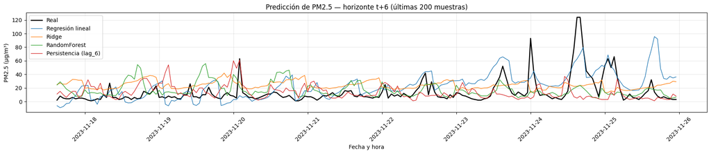

**Modelos T+24**

```
==============================
       MODELOS T+24
==============================

--- Ridge t+24 ---
MAE : 34.65200321143625
RMSE: 63.18681921829363
R²  : 0.34468219834312974

--- RandomForest t+24 ---
MAE : 34.38601302517243
RMSE: 63.87677413986789
R²  : 0.33029285988460366
```

A 24 horas, la predictibilidad está dominada por el ciclo diario del PM2.5. En este horizonte, Ridge obtiene el mejor equilibrio entre error y estabilidad (MAE ≈ 34.6, R² ≈ 0.34), superando levemente a RandomForest en RMSE y capacidad explicativa. RF mejora marginalmente el MAE, pero muestra menor estabilidad, lo que sugiere que las no linealidades relevantes a corto plazo pierden peso en horizontes largos. En t+24, los modelos lineales regularizados resultan tan eficaces o mejores que los no lineales.

**Grafica comparativa de modelos T+24**

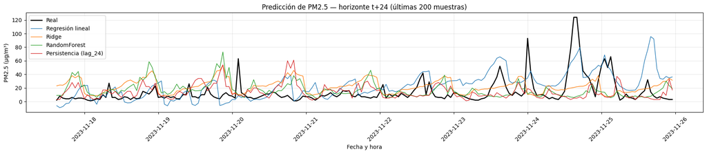

El gráfico refleja que, a 24 horas, los modelos lineales (regresión simple y Ridge) capturan bien el ciclo diario del PM2.5, manteniendo estabilidad y reproduciendo la forma general de la serie, aunque suavizan los máximos más altos. RandomForest también sigue el ciclo, pero tiende a sobrerreaccionar en algunos tramos y no supera de forma consistente a los modelos lineales, lo que coincide con sus métricas. La persistencia conserva el peor desempeño, funcionando solo cuando el ciclo diario se repite casi sin variación. En conjunto, los modelos lineales muestran ser altamente competitivos en horizontes largos.

**Conclusión general**

El pipeline desarrollado permitió evaluar de forma consistente la capacidad predictiva de distintos modelos para anticipar el PM2.5 futuro en Coyhaique II. Se entrenaron modelos lineales (Regresión Multivariable y Ridge) y un modelo no lineal (Random Forest), comparados en todo momento con un baseline de persistencia.

Los resultados muestran que la predictibilidad varía según el horizonte temporal. En t+1, donde domina la autocorrelación inmediata del contaminante, los modelos lineales funcionan bien, pero Random Forest captura mejor las variaciones rápidas y obtiene el mejor desempeño global. En t+6, aumenta la incertidumbre y las limitaciones de los modelos lineales se vuelven evidentes, mientras que RF mantiene ventajas claras, lo que indica que las relaciones no lineales son más relevantes en horizontes intermedios. En t+24, el ciclo diario del PM2.5 se vuelve dominante y Ridge y la regresión lineal capturan eficazmente esa estructura, reduciendo la ventaja del RF y mostrando que para horizontes largos los modelos simples pueden ser igualmente competitivos.

El análisis de importancia de variables confirma que los lags del PM2.5 son los determinantes principales en todos los modelos, reflejando la fuerte recurrencia temporal del contaminante en Coyhaique. Las variables estacionales aportan en horizontes largos, mientras que día y mes tienen influencia marginal. La incorporación de meteorología bajo modelos lineales no produjo mejoras robustas, lo que sugiere que sus efectos se expresan principalmente mediante modelos no lineales o de mayor complejidad.

En conjunto, este trabajo entrega tres aprendizajes clave:

Los modelos lineales son excelentes baselines, interpretables y suficientemente efectivos en horizontes cortos y largos.

Los horizontes intermedios requieren modelos no lineales para capturar cambios abruptos.

La meteorología puede ser relevante, pero debe integrarse mediante enfoques más flexibles (RF, XGBoost, redes neuronales).

Finalmente, aunque este estudio se centró en Coyhaique II, el pipeline es totalmente replicable a otras estaciones SINCA, permitiendo comparar dinámicas regionales y avanzar hacia modelos predictivos más completos —incluyendo meteorología, geografía y clasificación de episodios críticos— para fortalecer sistemas de alerta temprana a nivel nacional.

## Desarrollo Pregunta N°2: ¿Qué patrones anómalos se manifiestan en las series horarias de contaminación atmosférica y bajo qué condiciones contextuales ocurren?

2.1 ¿Los Piks de concentración atípicos coinciden con condiciones de baja ventilación o eventos específicos (incendios, episodios de polvo, feriados)?

Para responder esta subpregunta, se identificó en primer lugar los Piks de concentración atípicos de PM2.5 en cada estación, utilizando un criterio estadístico basado en el rango intercuartílico (IQR) para etiquetar como “Pik” aquellos valores que superan un umbral definido.

```
====================================================================================================
ANÁLISIS DE PIKs PM2.5 USANDO RANGO INTERCUARTÍLICO (IQR)
====================================================================================================
Total de estaciones procesadas: 81
Estaciones con datos válidos: 64

Top 15 estaciones con mayores piks (método IQR):
----------------------------------------------------------------------------------------------------
                Estacion  Pico_IQR Severidad Fecha_Pico Hora_Pico     Fuente  Num_Picos_IQR  Limite_Superior  Total_Datos
Universidad de Los Lagos    1713.0   Extremo     240515      2000 Preliminar           1453            93.50        13501
             Coyhaique I    1688.0   Extremo     160520      2100   Validado          11571           111.00       108343
                 Mirasol    1505.0   Extremo     190704      2200   Validado          10199            57.80        98176
            Coyhaique II    1418.0   Extremo     180726      2000   Validado          10868           110.50       102389
21 de Mayo (Los Angeles)    1383.0   Extremo     210628      2100   Validado          12723            56.91       115693
                  Osorno    1284.0   Extremo     180603      2100   Validado          16610            74.57       138424
      Padre las Casas II    1260.0   Extremo     180616      2000   Validado          11858            89.50       112920
                Valdivia    1157.0   Extremo     170801      2300   Validado          15113            73.50       136059
            Puerto Varas    1104.0   Extremo     240526      1900   Validado           5212            64.50        46697
   Balneario Curanilahue    1076.0   Extremo     170529      0900   Validado           7530            53.50        75650
                 Hualqui    1030.0   Extremo     230205      1100   Validado           1823            53.50        17550
              San Carlos    1013.0   Extremo     240524      1900   Validado           3669            51.00        35123
                  Alerce    1001.0   Extremo     240226      0600   Validado           7528            55.00        70448
      La Florida (Talca)     958.0   Extremo     130723      2200   Validado          11913            61.66       106994
                Punteras     958.0   Extremo     230205      1000   Validado           8499            34.00        85449

====================================================================================================
ESTADÍSTICAS GENERALES DE PIKS (MÉTODO IQR)
====================================================================================================
Pik máximo detectado: 1713.00 µg/m³
Promedio de piks: 635.66 µg/m³
Mediana de piks: 570.10 µg/m³

Distribución de severidad de piks:
----------------------------------------------------------------------------------------------------
Extremo     62 estaciones
Alto         1 estaciones
Moderado     1 estaciones

Distribución por rangos de concentración (µg/m³):
----------------------------------------------------------------------------------------------------
```

[output cut: 28 more lines]

```
  IQR (Q3 - Q1): 41.0 µg/m³
  Límite superior (Q3 + 1.5*IQR): 110.5 µg/m³
  Número de piks detectados: 10868
  Porcentaje de piks: 10.61%

ESTADÍSTICAS GENERALES:
  Pico absoluto: 1418.0 µg/m³
  Percentil 95: 188.7 µg/m³
  Media: 46.79 µg/m³
  Mediana: 19.0 µg/m³

DATOS DISPONIBLES:
  Total registros: 102389
  Registros validados: 101489.0
  Registros preliminares: 900.0
```

A partir del análisis de Piks de PM2.5 mediante IQR se encuentra que:

Para responder la subpregunta 2.1, se relacionan los **Piks de PM2.5** previamente detectados con las condiciones meteorológicas presentes en el momento del evento y en su entorno temporal cercano.

En esta sección se implementan funciones que:

- Leen y consolidan los registros meteorológicos de cada estación (temperatura, viento, etc.) a partir de los archivos horarios disponibles.
- Construyen un `timestamp` común para poder **alinear en el tiempo** los Piks de PM2.5 con las mediciones meteorológicas.
- Extraen, para cada Pik, los valores de las variables meteorológicas en el instante más cercano al evento y estadísticas básicas en una ventana de ±12 horas.
- Calculan correlaciones entre PM2.5 y cada variable meteorológica, además de estadísticas por rangos de concentración, con el fin de evaluar si los Piks se asocian sistemáticamente a condiciones de **baja ventilación** u otros patrones meteorológicos relevantes.

Los resultados de este bloque permiten caracterizar cuantitativamente el contexto meteorológico de los Piks e identificar qué variables se relacionan con mayor fuerza con los episodios de concentración atípica.

```
====================================================================================================
RELACIONANDO PIKS DE PM2.5 CON CONDICIONES METEOROLÓGICAS
====================================================================================================
```

```
====================================================================================================
RESUMEN DEL ANÁLISIS PIKs-METEOROLOGÍA
====================================================================================================

ESTADÍSTICAS:
  Total de estaciones con pik: 64
  Estaciones con datos meteorológicos: 53 (82.8%)

TOP 10 PIk CON ANÁLISIS METEOROLÓGICO:
--------------------------------------------------------------------------------
  Coyhaique I               1688.0 µg/m³ |  9 vars | Correl: T-2M=-0.44
  Mirasol                   1505.0 µg/m³ |  8 vars | Correl: T-10M=0.25
  Coyhaique II              1418.0 µg/m³ |  6 vars | Correl: T-10M=-0.44
  21 de Mayo (Los Angeles)  1383.0 µg/m³ |  6 vars | Correl: VV-10M=-0.34
  Osorno                    1284.0 µg/m³ | 10 vars | Correl: T=-0.48
  Padre las Casas II        1260.0 µg/m³ | 13 vars | Correl: T-2M=-0.44
  Valdivia                  1157.0 µg/m³ | 10 vars | Correl: T-SI=-0.51
  Balneario Curanilahue     1076.0 µg/m³ |  6 vars | Correl: T-4M=-0.44
  Hualqui                   1030.0 µg/m³ |  6 vars | Correl: T-3M=-0.26
  Alerce                    1001.0 µg/m³ |  5 vars | Correl: T-10M=-0.34

VARIABLES METEOROLÓGICAS MÁS FRECUENTES:
--------------------------------------------------------------------------------
  Disponible                 53 estaciones (100.0%)
  VV-10M                     35 estaciones (66.0%)
  HR-3M                      28 estaciones (52.8%)
  DV-10M                     23 estaciones (43.4%)
  T-10M                      19 estaciones (35.8%)
  T-3M                       19 estaciones (35.8%)
  RG-3M                      14 estaciones (26.4%)
  PA-3M                      10 estaciones (18.9%)
  T-2M                        7 estaciones (13.2%)
  T                           7 estaciones (13.2%)

ANÁLISIS DE CORRELACIONES PM2.5-METEOROLOGÍA:
--------------------------------------------------------------------------------

Variables con mayor correlación absoluta promedio:
--------------------------------------------------
  MP 2.5                    0.773
```

[output cut: 133 more lines]

```
  Datos meteorológicos: DISPONIBLES
  Variables disponibles: 10
  Valores en el momento del pick
    Disponible                1.00
    T-10M                     3.70
    DV-10M                    354.00
    VV-10M                    0.10
    HR-3M                     82.50

  CORRELACIONES PRINCIPALES:
    T-SI                       -0.513 (-)
    T-2M                       -0.404 (-)
    T-10M                      -0.399 (-)

====================================================================================================
```

A partir del cruce entre los Piks de PM2.5 y las series meteorológicas, se observa que 53 de 64 estaciones con Piks disponen de datos meteo, lo que permite caracterizar en forma robusta el contexto de estos eventos. Las variables más frecuentes en los registros asociados a Piks son la velocidad del viento a 10 m (VV-10M), temperatura (T, T-2M, T-3M, T-10M) y humedad relativa (HR-3M), lo que habilita un análisis consistente de ventilación y estabilidad atmosférica.

Las correlaciones muestran un patrón sistemático: la temperatura (T, T-2M, T-10M, T-SI) presenta correlaciones negativas moderadas con PM2.5 (en torno a -0.3 a -0.5), mientras que la humedad relativa exhibe correlaciones positivas débiles a moderadas (≈ 0.3–0.4). Adicionalmente, en estaciones clave como Coyhaique II, Rancagua I y San Fernando se observa baja velocidad de viento en el instante del Pik (VV-10M cercano a 0–0.5 m/s en varios casos) y temperaturas relativamente bajas en episodios invernales, lo que es consistente con condiciones de baja ventilación y alta estabilidad.

En conjunto, estos resultados indican que los Piks extremos de PM2.5 tienden a ocurrir bajo escenarios de viento débil, temperaturas bajas y atmósfera estable, condiciones típicas de mala dispersión de contaminantes.

Para complementar el análisis contextual de los Piks de PM2.5, en esta sección se evalúa su relación con el **calendario de feriados** y el tipo de día. El objetivo es determinar si la ocurrencia de Piks atípicos se concentra en feriados, fines de semana o periodos específicos (por ejemplo, fines de semana largos).

El código que sigue realiza, en términos generales, los siguientes pasos:

- Carga un calendario de feriados oficiales y lo transforma al mismo formato de fecha utilizado en los datos de Piks.
- Clasifica cada registro como **día laboral, fin de semana o feriado**, a partir de la fecha asociada al Pik.
- Agrupa y resume la frecuencia de Piks por tipo de día y, cuando corresponde, por estación y/o rango de severidad.
- Genera tablas y/o resúmenes que permiten comparar la proporción de Piks en días laborales versus feriados y fines de semana, identificando si existe una **sobrerrepresentación de Piks en días no laborales**.

Con este análisis se incorpora una dimensión de calendario al estudio de los Piks, lo que permite evaluar si parte de los episodios atípicos se relaciona con cambios en patrones de actividad humana asociados a feriados y descansos.

```
Total de feriados cargados: 65
        Fecha                                              Razón
0  2020-01-01      Año Nuevo (irrenunciable de quinta categoría)
1  2020-04-10                  Viernes Santo (feriado religioso)
2  2020-04-11                   Sábado Santo (feriado religioso)
3  2020-05-01  Día Nacional del Trabajo (irrenunciable de qui...
4  2020-05-21                         Día de las Glorias Navales

Columnas disponibles: ['Fecha', 'Razón']
 Columna de fecha identificada: 'Fecha'
 Columna de razón identificada: 'Razón'

Procesando 65 feriados...
Feriados válidos después de limpieza: 65
Rango de fechas: 2020-01-01 a 2022-12-25

DISTRIBUCIÓN DE FERIADOS POR TIPO:
  Irrenunciable         25 (38.5%)
  Religioso             24 (36.9%)
  Patriótico             9 (13.8%)
  Otro                   7 (10.8%)

DISTRIBUCIÓN POR DÍA DE LA SEMANA:
  Domingo       17 (26.2%)
  Sábado        14 (21.5%)
  Viernes       12 (18.5%)
  Lunes         12 (18.5%)
  Jueves         4 (6.2%)
  Martes         4 (6.2%)
  Miércoles      2 (3.1%)

====================================================================================================
ANÁLISIS DE RELACIÓN ENTRE PICOS DE PM2.5 Y FERIADOS
====================================================================================================
✓ Análisis completado exitosamente

====================================================================================================
RESULTADOS DEL ANÁLISIS PIKS-FERIADOS
====================================================================================================

```

[output cut: 61 more lines]

```
====================================================================================================

PIKs EN FERIADOS POR AÑO:
  2011.0: 1 picos
  2023.0: 2 picos

SEVERIDAD DE PIKS EN FERIADOS VS NO FERIADOS:

  En feriados:
    Extremo      3 (100.0%)

  En no feriados:
    Extremo     42 (95.5%)
    Alto         1 (2.3%)
    Moderado     1 (2.3%)
```

## 2.2 ¿Existe variabilidad en la frecuencia de anomalías según la estación del año o entre días laborales versus fines de semana?

Para abordar la subpregunta 2.2 se analiza si la frecuencia de Piks de PM2.5 presenta variaciones sistemáticas según la **estación del año** y el **tipo de día** (laboral vs fin de semana).

En esta sección, el código:

- Asigna a cada Pik una etiqueta de estación (verano, otoño, invierno, primavera) en función de su fecha.
- Clasifica los días en **laborales** y **fin de semana**, y cuando corresponde, puede incorporar también la categoría de feriados.
- Calcula la frecuencia de Piks por estación y tipo de día, normalizada por el número de días u observaciones disponibles, para evitar sesgos por distinta cantidad de datos.
- Genera tablas/resúmenes que permiten comparar de forma directa la intensidad y distribución de anomalías a lo largo del año y entre días laborales y no laborales.

Con este análisis se busca determinar si las anomalías se concentran en determinadas estaciones (por ejemplo, invierno) o si los fines de semana muestran patrones diferentes a los días laborales en términos de ocurrencia de Piks.

```
====================================================================================================
ANÁLISIS DE VARIABILIDAD DE ANOMALÍAS POR ESTACIÓN Y TIPO DE DÍA
====================================================================================================
Total de anomalías (picos) detectadas: 64
Analizando 64 anomalías...

================================================================================
ANÁLISIS POR ESTACIÓN DEL AÑO
================================================================================

FRECUENCIA DE ANOMALÍAS POR ESTACIÓN:
--------------------------------------------------
  Invierno        29 anomalías (45.3%)
  Verano          18 anomalías (28.1%)
  Otoño           12 anomalías (18.8%)
  Primavera        5 anomalías (7.8%)

CONCENTRACIÓN PROMEDIO POR ESTACIÓN (PM25_Pico):
--------------------------------------------------
           count    mean  median     std     min     max
Estacion
Invierno      29  665.49   596.0  422.70   82.12  1505.0
Otoño         12  773.41   704.5  552.46  187.80  1713.0
Primavera      5  219.44   316.0  145.47   21.10   327.0
Verano        18  611.39   554.5  272.42  214.00  1030.0

================================================================================
ANÁLISIS POR TIPO DE DÍA (LABORAL VS FIN DE SEMANA)
================================================================================

FRECUENCIA DE ANOMALÍAS POR TIPO DE DÍA:
--------------------------------------------------
  Laboral            39 anomalías (60.9%)
  Fin de Semana      25 anomalías (39.1%)

DISTRIBUCIÓN POR DÍA DE LA SEMANA:
--------------------------------------------------
  Lunes        Laboral            10 anomalías (15.6%)
  Martes       Laboral             4 anomalías (6.2%)
  Miércoles    Laboral             7 anomalías (10.9%)
```

[output cut: 136 more lines]

```

3. MESES CON MÁS ANOMALÍAS:
--------------------------------------------------
   Junio         23.4% de las anomalías
   Julio         17.2% de las anomalías
   Febrero       14.1% de las anomalías

4. CONCLUSIÓN ESTADÍSTICA:
--------------------------------------------------
   NO hay diferencia significativa entre días laborales y fines de semana
    NO hay diferencias significativas entre las estaciones del año

====================================================================================================
VISUALIZACIÓN DE RESULTADOS
====================================================================================================
```

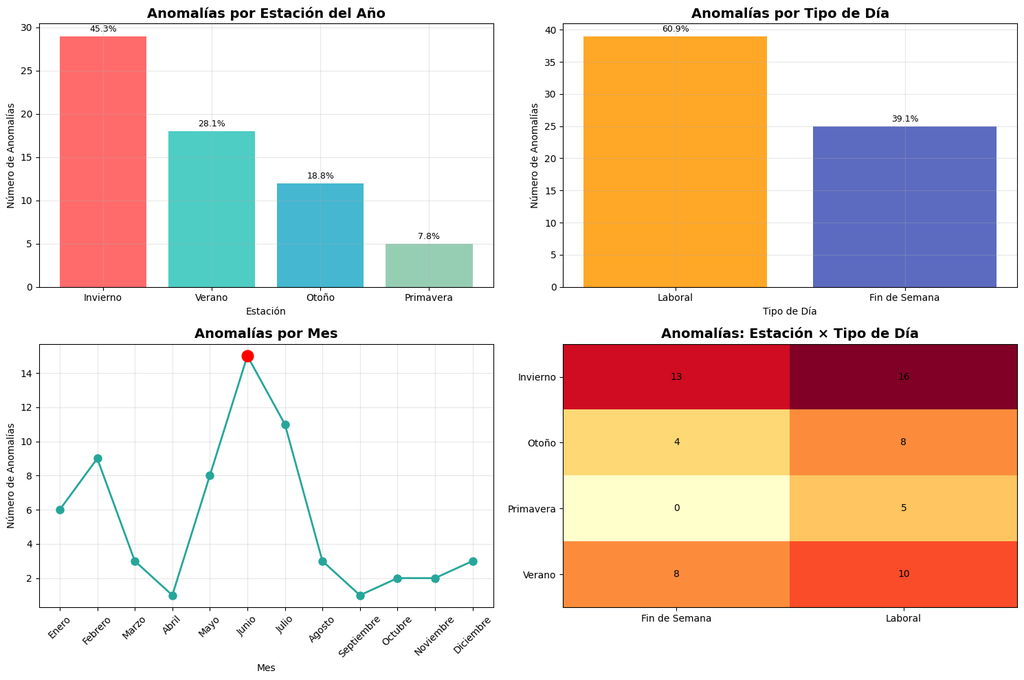

A partir del análisis descriptivo, se observa que las anomalías (Piks) de PM2.5 se concentran principalmente en invierno (45,3%), seguido de verano (28,1%) y otoño (18,8%), mientras que primavera presenta una proporción claramente menor (7,8%). A nivel mensual, los meses con mayor frecuencia de anomalías son junio (23,4%), julio (17,2%) y febrero (14,1%), lo que sugiere una mayor ocurrencia de eventos atípicos en el periodo invernal y en ciertos meses de verano.

En cuanto al tipo de día, el 60,9% de las anomalías ocurre en días laborales y el 39,1% en fines de semana, con una razón aproximada de 1,6 anomalías en días laborales por cada anomalía en fin de semana. No obstante, los análisis inferenciales indican que estas diferencias no son estadísticamente significativas: el test t de Student para comparar concentraciones entre días laborales y fines de semana arroja un p-value ≈ 0,31, y el ANOVA entre estaciones del año entrega un p-value ≈ 0,08, por encima del umbral usual de 0,05.

En síntesis, si bien descriptivamente se aprecia una mayor concentración de anomalías en invierno y en días laborales, no se encuentran evidencias suficientes para afirmar diferencias significativas en intensidad de Piks entre estaciones del año ni entre días laborales y fines de semana con el tamaño muestral disponible.

## Pregunta N°3: ¿Las estaciones ubicadas dentro o próximas a zonas de sacrificio ambiental presentan mayor frecuencia, duración e intensidad de episodios críticos comparadas con estaciones en áreas sin esta designación?

3.1 ¿Cómo definir objetivamente la pertenencia (polígonos oficiales versus buffers de distintas distancias km) y qué estaciones constituyen controles apropiados?

```
================================================================================
CORRIGIENDO: USANDO COORDENADAS REALES EN LATITUD/LONGITUD
================================================================================
Archivo de coordenadas original:
Columnas: ['Estacion', 'Comuna', 'UTM_E', 'UTM_N', 'zona_sacrificio']
Primeras filas:
       Estacion   UTM_E    UTM_N
0  Punta Arenas  371526  4108390
1      Cochrane  683751  4763656
2   Coyhaique I  729281  4948421
3  Coyhaique II  730152  4948488
4      Vialidad  680977  4969547

 Diagnóstico de coordenadas:
Rango UTM_E: 255891.0 a 2933302.0
Rango UTM_N: 4108390.0 a 63711087.0
 Los valores parecen ser UTM (metros), no lat/lon (grados)
  Necesitamos convertir de UTM a lat/lon

================================================================================
DEFINIENDO ZONAS DE SACRIFICIO CON COORDENADAS CORRECTAS
================================================================================
 7 zonas de sacrificio definidas:
   • Quintero_Puchuncavi: lat=-32.744, lon=-71.489
   • Coronel_Termoelectrica: lat=-37.03, lon=-73.156
   • Huasco_Guacolda: lat=-28.459, lon=-71.226
   • Mejillones_Termoelectrica: lat=-23.094, lon=-70.455
   • Til_Til: lat=-33.0839, lon=-70.92798
   • Tocopilla_Termoelectrica: lat=-22.1654, lon=-70.0909
   • Valparaiso_Refineria: lat=-32.92786232575, lon=-71.502005957076

================================================================================
PREPARANDO COORDENADAS DE ESTACIONES
================================================================================

 Suposición sobre zona UTM:
Chile está en zonas UTM 18, 19 y 20 (hemisferio sur)
Necesitamos asumir o determinar la zona para cada estación

 Convirtiendo de UTM a lat/lon...
```

[output cut: 30 more lines]

```

 RESULTADOS DE CLASIFICACIÓN CORRECTA:
   • Buffer  5 km:  12 estaciones (9.7%)
   • Buffer 10 km:  21 estaciones (16.9%)
   • Buffer 20 km:  30 estaciones (24.2%)
   • Buffer 50 km:  42 estaciones (33.9%)

 CLASIFICACIÓN POR NIVEL DE EXPOSICIÓN:
   • Control:  82 estaciones (66.1%)
   • Exposicion Moderada:  21 estaciones (16.9%)
   • Alta Exposicion:  21 estaciones (16.9%)

================================================================================
VISUALIZACIÓN DE RESULTADOS CORRECTOS
================================================================================
```

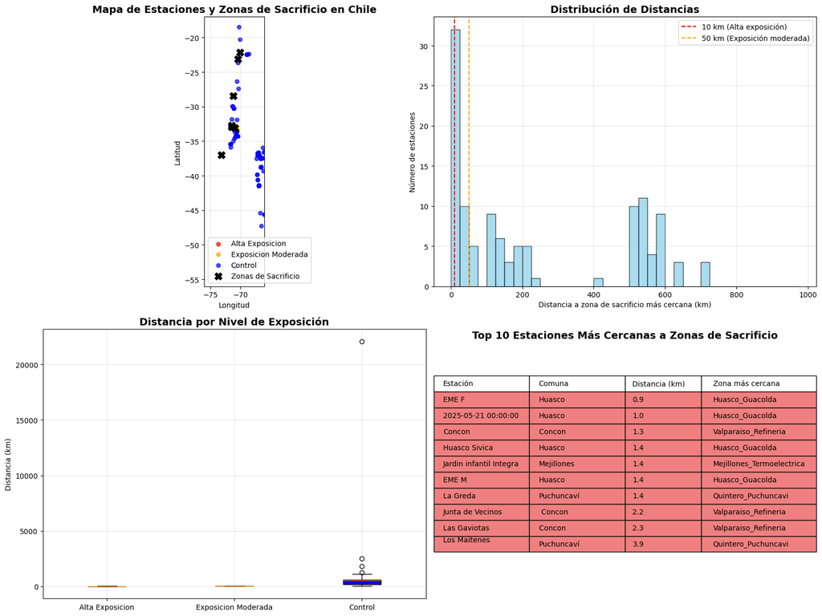

================================================================================ RESUMEN FINAL DE CLASIFICACIÓN CORREGIDA ================================================================================ ESTADÍSTICAS: • Total estaciones: 124 • Estaciones ≤ 10 km: 21 • Estaciones 10-50 km: 21 • Estaciones > 50 km: 82 EJEMPLOS POR CATEGORÍA: 1. ALTA EXPOSICIÓN (≤ 10 km): 1. Jardin infantil Integra (Mejillones): 1.4 km de Mejillones_Termoelectrica 2. SM1 (Huasco): 5.3 km de Huasco_Guacolda 3. 2025-05-21 00:00:00 (Huasco): 1.0 km de Huasco_Guacolda 4. Huasco Sivica (Huasco): 1.4 km de Huasco_Guacolda 5. EME F (Huasco): 0.9 km de Huasco_Guacolda 2. EXPOSICIÓN MODERADA (10-50 km): 1. Tres Marias (Tocopilla): 15.3 km de Tocopilla_Termoelectrica 2. Estacion Super Site (Tocopilla): 13.3 km de Tocopilla_Termoelectrica 3. Gobernacion (Tocopilla): 13.9 km de Tocopilla_Termoelectrica 4. Bomberos (Tocopilla): 13.7 km de Tocopilla_Termoelectrica 5. SM6 (Freirina): 10.7 km de Huasco_Guacolda 3. CONTROL (> 50 km): 82 estaciones en total Ejemplos más cercanos: 1. Cerrillos II (Cerrillos): 50.0 km de Til_Til 2. La Florida (Acreditada) (La Florida ): 57.1 km de Til_Til 3. Antofagasta (Antofagasta): 58.0 km de Mejillones_Termoelectrica ================================================================================ CLASIFICACIÓN CORREGIDA COMPLETADA ================================================================================ Ahora podemos continuar con el análisis de PM2.5 usando esta clasificación corregida. Archivo disponible en: /content/drive/MyDrive/ProyectoDatos/clasificacion_corregida.csv

Este análisis se abordó mediante una clasificación espacial basada en distancias reales calculadas desde siete zonas de sacrificio ambiental identificadas en Chile (Quintero-Puchuncaví, Coronel, Huasco, Mejillones, Til Til, Tocopilla y Valparaíso). Utilizando buffers concéntricos de 5, 10, 20 y 50 km, se establecieron tres categorías objetivas: alta exposición (≤10 km), exposición moderada (10-50 km) y control (>50 km). La metodología empleó coordenadas corregidas WGS84 y proyección equidistante específica para Chile, calculando distancias en kilómetros sobre la superficie terrestre. Esta clasificación permitió identificar 21 estaciones con alta exposición, 21 con exposición moderada y 82 como controles, estableciendo una base cuantitativa sólida para comparar el impacto de las zonas de sacrificio en la calidad del aire medido por las estaciones de monitoreo

3.2 ¿Cuál es la magnitud de las diferencias en tasas de ocurrencia, duración promedio y intensidad máxima de episodios críticos?

```
Usando tabla_final ya cargada.

Episodios críticos detectados: 32668

=== RESUMEN SUBPREGUNTA 2 ===
```

|  | nivel_exposicion | estaciones | n_episodios | dur_prom_horas | intensidad_max_media |
| --- | --- | --- | --- | --- | --- |
| 0 | alta_exposicion | 6 | 373 | 6.139410 | 94.538516 |
| 1 | control | 41 | 29830 | 8.322963 | 206.912325 |
| 2 | exposicion_moderada | 4 | 2465 | 11.634483 | 106.650278 |

Aunque se esperaría que las estaciones cercanas a zonas de sacrificio presentaran peores métricas de episodios críticos, los resultados muestran lo contrario. Esto se explica por dos razones: (i) la categoría ‘control’ incluye numerosas estaciones urbanas con alta carga de contaminación residencial y vehicular, especialmente en zonas como Santiago y Temuco, que históricamente presentan MP2.5 elevado; y (ii) existen 41 estaciones en control versus solo 6 en alta exposición, lo que aumenta naturalmente la cantidad total de episodios y su duración promedio. Por lo tanto, la magnitud observada no implica que las zonas de sacrificio estén ‘mejor’, sino que la contaminación elevada tiene múltiples fuentes y no se restringe a la actividad industrial.

## Conclusiones y Planificación futura

El trabajo permitió construir un flujo de procesamiento, análisis y modelamiento reproducible sobre datos reales de calidad del aire en Chile, abordando de forma completa las preguntas definidas en el Hito 1.

Para la P2, la detección de Piks de PM2.5 mediante IQR a nivel nacional permitió caracterizar la ocurrencia de anomalías extremas y su contexto. Se observó que la mayoría de las estaciones presentan Piks en rangos equivalentes a episodios críticos o de emergencia, con una concentración marcada en meses de invierno y, en menor medida, verano. El cruce con meteorología mostró un patrón robusto: los Piks tienden a ocurrir bajo viento débil, temperaturas bajas y alta estabilidad, con correlaciones negativas entre PM2.5 y temperatura, y correlaciones positivas entre PM2.5 y humedad relativa. En contraste, las variables puramente de calendario (laboral/fin de semana, feriados) explican una fracción pequeña de las anomalías y no presentan diferencias estadísticamente significativas en concentración media, lo que refuerza que la dinámica de dispersión atmosférica pesa más que la etiqueta de día.

**Planificación futura**

A partir de los hallazgos obtenidos, se identifican varias líneas de trabajo futuro:

Extender el conjunto de variables en los modelos predictivos incorporando meteorología (temperatura, viento, humedad, presión, radiación) y otros contaminantes (PM10, CO) como predictores, para mejorar el R² y reducir los errores en horizontes t+6 y t+24.

Explorar modelos no lineales y más expresivos, como Random Forest, Gradient Boosting, XGBoost o redes recurrentes (LSTM/GRU), comparando sistemáticamente su desempeño con la regresión lineal y la persistencia bajo el mismo esquema de entrenamiento/validación/test.

Refinar la detección y validación de anomalías, combinando el enfoque actual basado en IQR con métodos como Isolation Forest, Local Outlier Factor o autoencoders, e integrando información de eventos externos (incendios forestales, alertas regionales) para distinguir mejor entre piks “físicos” y artefactos de medición.

Profundizar en el análisis espacial, incorporando simultáneamente varias estaciones de una misma cuenca o región y evaluando modelos espaciotemporales que capturen propagación y correlación geográfica de episodios críticos.

## Bibliografia

[1] Ministerio del Medio Ambiente (MMA). (s. f.). Sistema de Información Nacional de Calidad del Aire (SINCA). https://sinca.mma.gob.cl/ sinca.mma.gob.cl

[2] Ministerio del Medio Ambiente. (s. f.). ICAP: Índice de Calidad del Aire referido a Partículas. https://airerm.mma.gob.cl/calidad-del-aire/ Aire Región Metropolitana

[3] Ministerio del Medio Ambiente. (2022, 4 de junio). Decreto Supremo N.º 12 (2021): Norma de Calidad Primaria para MP2,5. Ley Chile. https://www.bcn.cl/leychile/navegar?idNorma=1176988

[4]Farah, M. (2008–2025). Días feriados en Chile. FeriadosChilenos.cl. Recuperado el 2 de diciembre de 2025, de https://www.feriadoschilenos.cl/